# Chapter 4 - PCA: computer exercises

Author

Prof. Richard Wilkinson

### Q1

Using the `iris` dataset, familiarize yourself with the `prcomp` command and its output.

**Solution**

```r
head(iris) # always look at the data first.
```

```
  Sepal.Length Sepal.Width Petal.Length Petal.Width Species
1          5.1         3.5          1.4         0.2  setosa
2          4.9         3.0          1.4         0.2  setosa
3          4.7         3.2          1.3         0.2  setosa
4          4.6         3.1          1.5         0.2  setosa
5          5.0         3.6          1.4         0.2  setosa
6          5.4         3.9          1.7         0.4  setosa
```

```r
X<- as.matrix(iris[,1:4])
X.pca <- prcomp(X)
print(X.pca)
```

```
Standard deviations (1, .., p=4):
[1] 2.0562689 0.4926162 0.2796596 0.1543862

Rotation (n x k) = (4 x 4):
                     PC1         PC2         PC3        PC4
Sepal.Length  0.36138659 -0.65658877  0.58202985  0.3154872
Sepal.Width  -0.08452251 -0.73016143 -0.59791083 -0.3197231
Petal.Length  0.85667061  0.17337266 -0.07623608 -0.4798390
Petal.Width   0.35828920  0.07548102 -0.54583143  0.7536574
```

```r
summary(X.pca)
```

```
Importance of components:
                          PC1     PC2    PC3     PC4
Standard deviation     2.0563 0.49262 0.2797 0.15439
Proportion of Variance 0.9246 0.05307 0.0171 0.00521
Cumulative Proportion  0.9246 0.97769 0.9948 1.00000
```

This has done PCA on the covariance matrix. The print command prints out the eigenvectors and the square root of the eigenvalues. To instead to PCA on the correlation matrix use:

```r
X.pca.scaled<-prcomp(X, scale=TRUE) # uses correlation matrix
```

We can access the individual components as follows:

```r
X.pca$sdev  # the square root of the eigenvecotrs
```

```
[1] 2.0562689 0.4926162 0.2796596 0.1543862
```

```r
X.pca$rotation ## the loadings/eigenvectors
```

```
                     PC1         PC2         PC3        PC4
Sepal.Length  0.36138659 -0.65658877  0.58202985  0.3154872
Sepal.Width  -0.08452251 -0.73016143 -0.59791083 -0.3197231
Petal.Length  0.85667061  0.17337266 -0.07623608 -0.4798390
Petal.Width   0.35828920  0.07548102 -0.54583143  0.7536574
```

```r
X.pca$center  # the sample mean
```

```
Sepal.Length  Sepal.Width Petal.Length  Petal.Width
    5.843333     3.057333     3.758000     1.199333
```

```r
X.pca$scale # TRUE if correlation matrix used, or FALSE if covariance matrix used.
```

```
[1] FALSE
```

```r
head(X.pca$x)  # the scores
```

```
           PC1        PC2         PC3          PC4
[1,] -2.684126 -0.3193972  0.02791483  0.002262437
[2,] -2.714142  0.1770012  0.21046427  0.099026550
[3,] -2.888991  0.1449494 -0.01790026  0.019968390
[4,] -2.745343  0.3182990 -0.03155937 -0.075575817
[5,] -2.728717 -0.3267545 -0.09007924 -0.061258593
[6,] -2.280860 -0.7413304 -0.16867766 -0.024200858
```

When we do PCA with the correlation matrix, circle plots give us a way of interpretting the principal components:

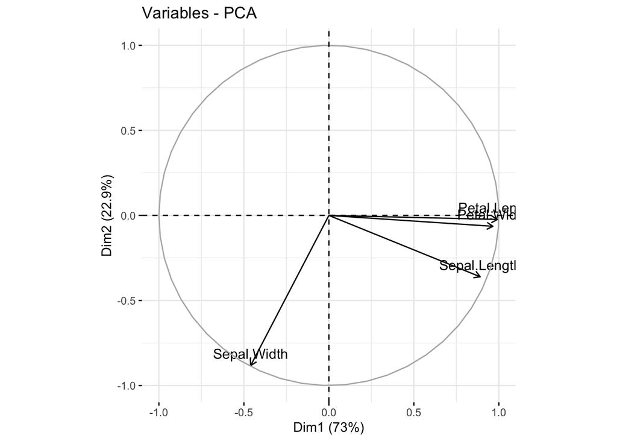

```r
library(factoextra)
# you will need to install the factoextra
# package the first time you use it.

fviz(X.pca.scaled, element='var')
```

They plot the correlation between the first two transformed scores, $y_1$ and $y_2$, and the original variables $x_i$.

```r
cor(cbind(X.pca.scaled$x[,1:2], X))[3:6, 1:2]
```

```
                    PC1         PC2
Sepal.Length  0.8901688 -0.36082989
Sepal.Width  -0.4601427 -0.88271627
Petal.Length  0.9915552 -0.02341519
Petal.Width   0.9649790 -0.06399985
```

This allows us to see that PC1 is primarily a measure of petal length and width and sepal length, whereas PC2 is a measure of sepal width.

It is plotted on a circle because it is possible to show that
$$\sum_{j=1}^p {\mathbb{C}\operatorname{or}}(y_j, x_i)^2 = 1$$
where $x_i$ are the original variables, and $y_j$ the transformed variables. Thus
$$\mathbb{C}\operatorname{or}(y_1,x_i)^2+\mathbb{C}\operatorname{or}(y_2, x_i)^2\leq 1.$$

You can read more about the plotting ability of `fviz` [here](http://www.sthda.com/english/wiki/fviz-pca-quick-principal-component-analysis-data-visualization-r-software-and-data-mining). It is possible to do some elegant plots showing the projected data, on top of the circle correlations allowing us to really see the difference between the groups. For example:

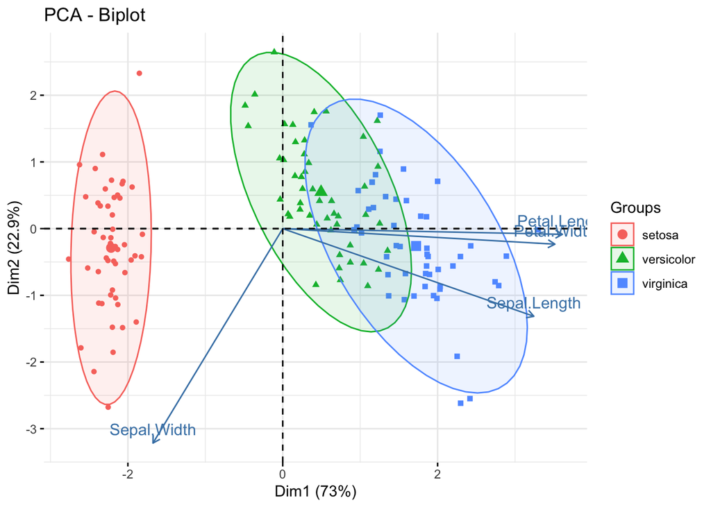

```r
fviz_pca_biplot(X.pca.scaled, label = "var", habillage=iris$Species,
               addEllipses=TRUE, ellipse.level=0.95,
               ggtheme = theme_minimal())
```

Now, instead of using `prcomp` we will do the analysis ourselves using the `eigen` command.

- Start by computing the sample mean and sample variance of the dataset (use $n-1$ as the denominator when you compute the sample variance to get the same answer as provided by `prcomp`).

**Solution**

```r
xbar = colMeans(X)
cov(X)
```

```
             Sepal.Length Sepal.Width Petal.Length Petal.Width
Sepal.Length    0.6856935  -0.0424340    1.2743154   0.5162707
Sepal.Width    -0.0424340   0.1899794   -0.3296564  -0.1216394
Petal.Length    1.2743154  -0.3296564    3.1162779   1.2956094
Petal.Width     0.5162707  -0.1216394    1.2956094   0.5810063
```

```r
Xcent = sweep(X,2,xbar) # HX
S = t(Xcent)%*%Xcent/149 # should agree with cov(X)
```

- Now compute the eigenvalues and eigenvectors of the covariance matrix using `eigen`. Check that these agree with those computed by `prcomp` (noting that `prcomp` returns the standard deviation which is the square root of the eigenvalues).

**Solution**

```r
(S.eig = eigen(S))
```

```
eigen() decomposition
$values
[1] 4.22824171 0.24267075 0.07820950 0.02383509

$vectors
            [,1]        [,2]        [,3]       [,4]
[1,]  0.36138659  0.65658877 -0.58202985  0.3154872
[2,] -0.08452251  0.73016143  0.59791083 -0.3197231
[3,]  0.85667061 -0.17337266  0.07623608 -0.4798390
[4,]  0.35828920 -0.07548102  0.54583143  0.7536574
```

```r
X.pca$rotation -S.eig$vectors
```

```
                       PC1        PC2        PC3           PC4
Sepal.Length -1.665335e-16 -1.3131775  1.1640597  4.996004e-16
Sepal.Width  -1.110223e-16 -1.4603229 -1.1958217 -6.106227e-16
Petal.Length  2.220446e-16  0.3467453 -0.1524722  5.551115e-17
Petal.Width   2.220446e-16  0.1509620 -1.0916629 -5.551115e-16
```

What has gone wrong - why don’t they agree? Two things have happened. Firstly there are small numerical errors that occur due to rounding errors. The second is that the eigenvectors are only determined upto multiplication by $\pm 1$. If we divide them, we can see they are essentially the same:

```r
X.pca$rotation/S.eig$vectors
```

```
             PC1 PC2 PC3 PC4
Sepal.Length   1  -1  -1   1
Sepal.Width    1  -1  -1   1
Petal.Length   1  -1  -1   1
Petal.Width    1  -1  -1   1
```

We can also check that the standard deviations agree with the eigenvalues.

```r
X.pca$sdev^2
```

```
[1] 4.22824171 0.24267075 0.07820950 0.02383509
```

```r
S.eig$values
```

```
[1] 4.22824171 0.24267075 0.07820950 0.02383509
```

```r
X.pca$sdev^2- S.eig$values
```

```
[1]  3.552714e-15  3.330669e-16  8.326673e-17 -1.491862e-16
```

- Now compute the principal component scores by multiplying $\mathbf X$ by the matrix of eigenvectors $\mathbf V$. Check your answer agrees with the scores provided by `prcomp`.

**Solution**

```r
scores = Xcent%*%S.eig$vectors
## note must use Xcent!

head(X.pca$x/ scores)
```

```
     PC1 PC2 PC3 PC4
[1,]   1  -1  -1   1
[2,]   1  -1  -1   1
[3,]   1  -1  -1   1
[4,]   1  -1  -1   1
[5,]   1  -1  -1   1
[6,]   1  -1  -1   1
```

So the scores (transformed variables) agree.

Now we will do the same thing again, but using the `svd` command.

- Compute the column centred data matrix $\frac{1}{\sqrt{n-1}}\mathbf H\mathbf X$.

**Solution**

```r
Xtilde = Xcent/sqrt(149)
```

- Compute the SVD of $\frac{1}{\sqrt{n-1}}\mathbf H\mathbf X$ and $\mathbf H\mathbf X$. How are the two sets of singular values related, and how do they relate to the eigenvalues computed previously. Are the singular vectors of $\frac{1}{\sqrt{n-1}}\mathbf H\mathbf X$ and $\mathbf H\mathbf X$ the same?

**Solution**

Iif we scale $X$, then the singular values are scaled by the same amount.

```r
svd(Xtilde)$d - svd(Xcent)$d/sqrt(149)
```

```
[1] -8.881784e-16 -4.440892e-16 -5.551115e-17 -8.326673e-17
```

```r
#Singular values of
#HX/sqrt(149) = sqrt(eigenvalues S)
```

But scaling $X$ doesn’t change the singular vectors:

```r
head(svd(Xcent)$v/svd(Xtilde)$v )
```

```
     [,1] [,2] [,3] [,4]
[1,]    1    1    1    1
[2,]    1    1    1    1
[3,]    1    1    1    1
[4,]    1    1    1    1
```

```r
#also try:
#head(svd(Xcent)$u/svd(Xtilde)$u)
```

Let’s check the singular values agree with the standard deviations computed by `prcomp`:

```r
svd(Xtilde)$d - X.pca$sdev
```

```
[1] -8.881784e-16 -4.440892e-16 -5.551115e-17 -8.326673e-17
```

```r
#svd(Xcent)$d/sqrt(149) - X.pca$sdev # this is what R does
```

- Compute the SVD scores by doing both $\mathbf H\mathbf X\mathbf V$ and $\mathbf U\boldsymbol{\Sigma}$, where
  $$\mathbf H\mathbf X= \mathbf U\boldsymbol{\Sigma}\mathbf V^\top$$
  is the SVD of $\mathbf H\mathbf X$.

**Solution**

Finally, let’s check the scores agree by doing both $\mathbf H\mathbf X\mathbf V$ and $\mathbf U\boldsymbol{\Sigma}$, where
$$\mathbf H\mathbf X= \mathbf U\boldsymbol{\Sigma}\mathbf V^\top$$
is the SVD of $\mathbf H\mathbf X$.

```r
scores = Xcent%*% svd(Xcent)$v
head(scores/X.pca$x)
```

```
     PC1 PC2 PC3 PC4
[1,]   1   1   1   1
[2,]   1   1   1   1
[3,]   1   1   1   1
[4,]   1   1   1   1
[5,]   1   1   1   1
[6,]   1   1   1   1
```

```r
#U Sigma
head(svd(Xcent)$u %*% diag(svd(Xcent)$d)/X.pca$x)
```

```
     PC1 PC2 PC3 PC4
[1,]   1   1   1   1
[2,]   1   1   1   1
[3,]   1   1   1   1
[4,]   1   1   1   1
[5,]   1   1   1   1
[6,]   1   1   1   1
```

```r
# Note that this is using Sigma for HX
#not HX/sqrt(n)
```

### Q2

In this question we will look at the crabs data from the `MASS` R package. We will focus on the 5 continuous variables, all measured in mm:

- FL = frontal lobe size
- RW = rear width
- CL = carapace length
- CW = carapace width
- BD = body depth.

```r
library(MASS)
?crabs # look at the help page.
X = crabs[,4:8]
```

- Carry out PCA on the data in $X$ using the correlation matrix, including obtaining a scree plot and plotting the PC scores.

**Solution**

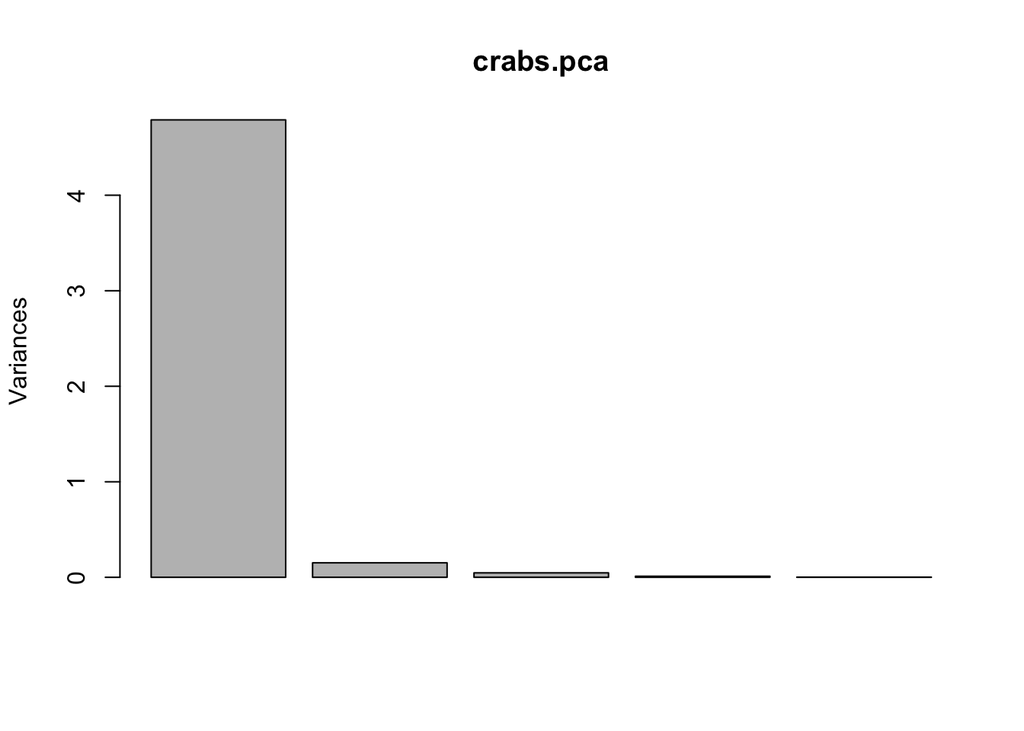

```r
crabs.pca <- prcomp(X, scale=TRUE) # do PCA
plot(crabs.pca) # scree plot
```

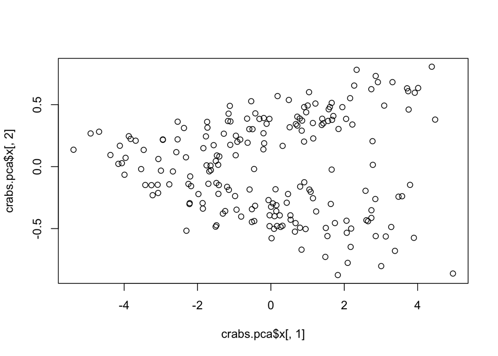

```r
plot(crabs.pca$x[,1], crabs.pca$x[,2]) # PC2 vs PC1.
```

By adding colour we can see some patterns. The easiest way is to install the ggfortify package.

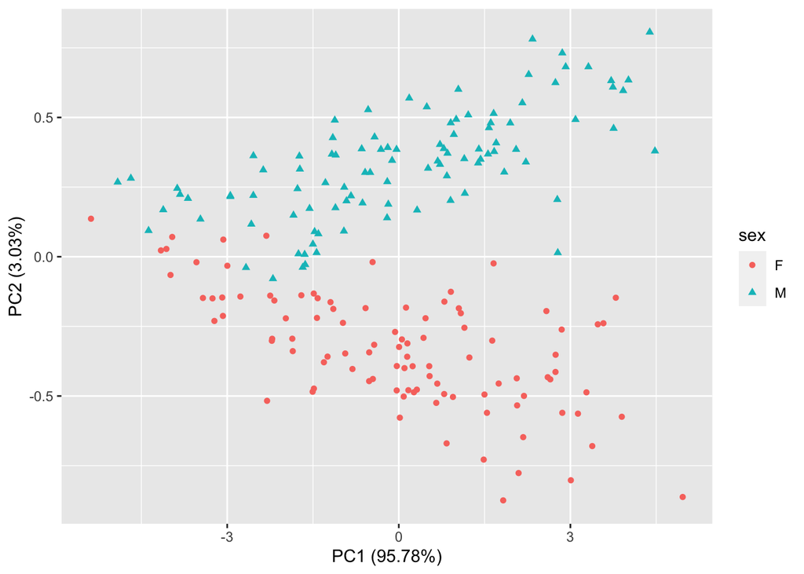

```r
library(ggfortify)
autoplot(crabs.pca, data = crabs, colour='sex', scale=FALSE, shape='sex')
```

This has coloured the points by sex. We can see there is clearly a difference between male and female crabs.

- Do you have any suggestions for an interpretation for the first two principal components? Circle plots may help.

**Solution**

The first PC appears to be a measure of overall size:

```r
crabs.pca$rotation[,1]
```

```
       FL        RW        CL        CW        BD
0.4520437 0.4280774 0.4531910 0.4511127 0.4511336
```

The second PC primarily measures RW. However, as it only represents 3% of the total variation, it is not worth thinking too hard about an interpretation (there is a risk of over-interpretting and reading too much into random noise).

```r
crabs.pca$rotation[,2]
```

```
        FL         RW         CL         CW         BD
 0.1375813 -0.8981307  0.2682381  0.1805959  0.2643219
```

The circle plot confirms this interpretation:

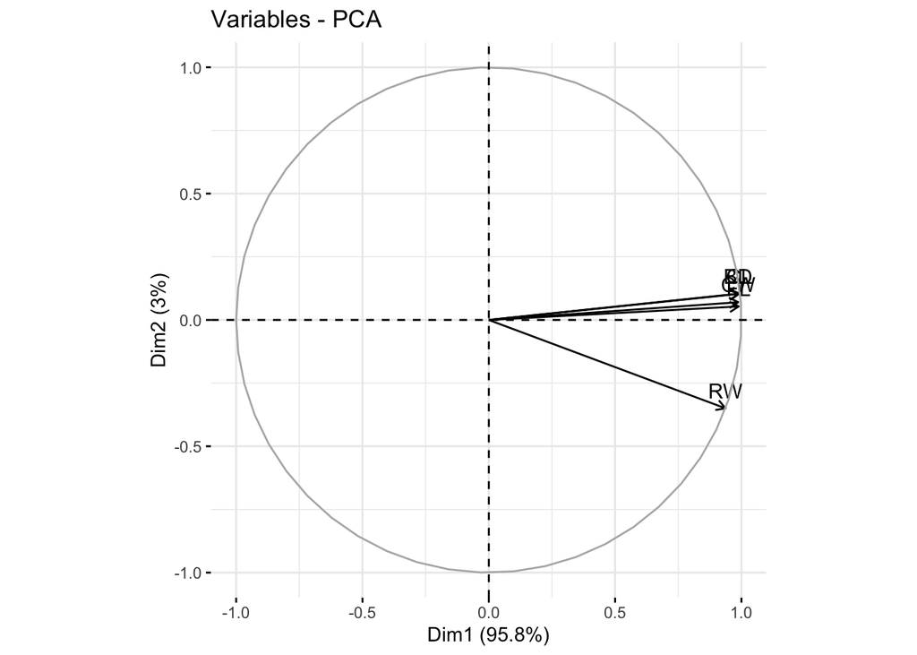

```r
fviz(crabs.pca, element='var')
```

Note that there is a clear sex dependence here; female crabs have smaller PC2 score.

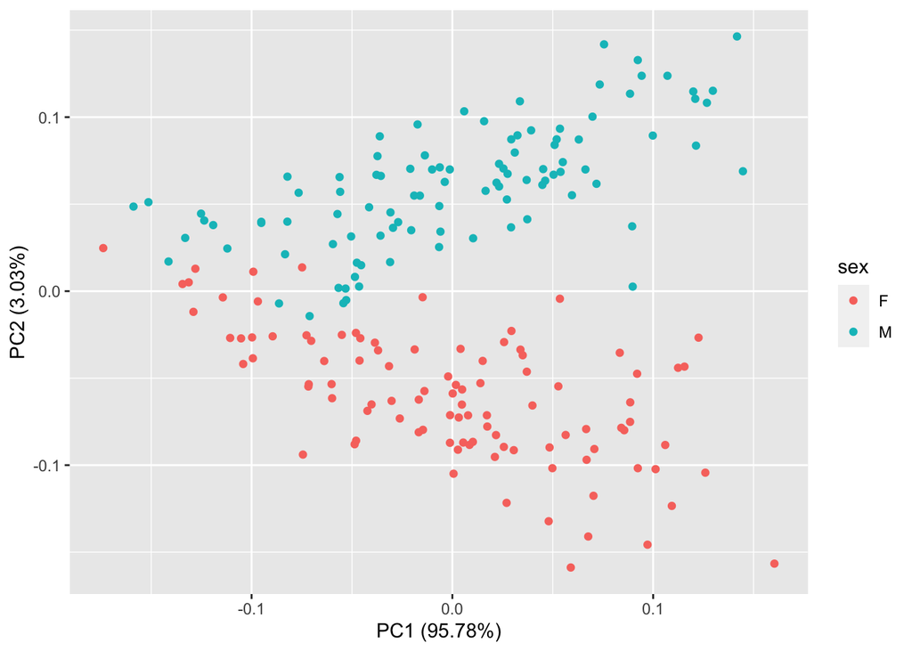

```r
autoplot(crabs.pca, data = crabs, colour='sex')
```

- Do you think an analysis based on the sample covariance matrix ${\bf S}$ or the correlation matrix ${\bf R}$ is preferable with this dataset?

**Solution**

This doesn’t make a big difference as the measurements are all on the same scale and only differ by a factor of 2. It does alter the interpretations a little, but PC1 is still largely a measure of overall size.

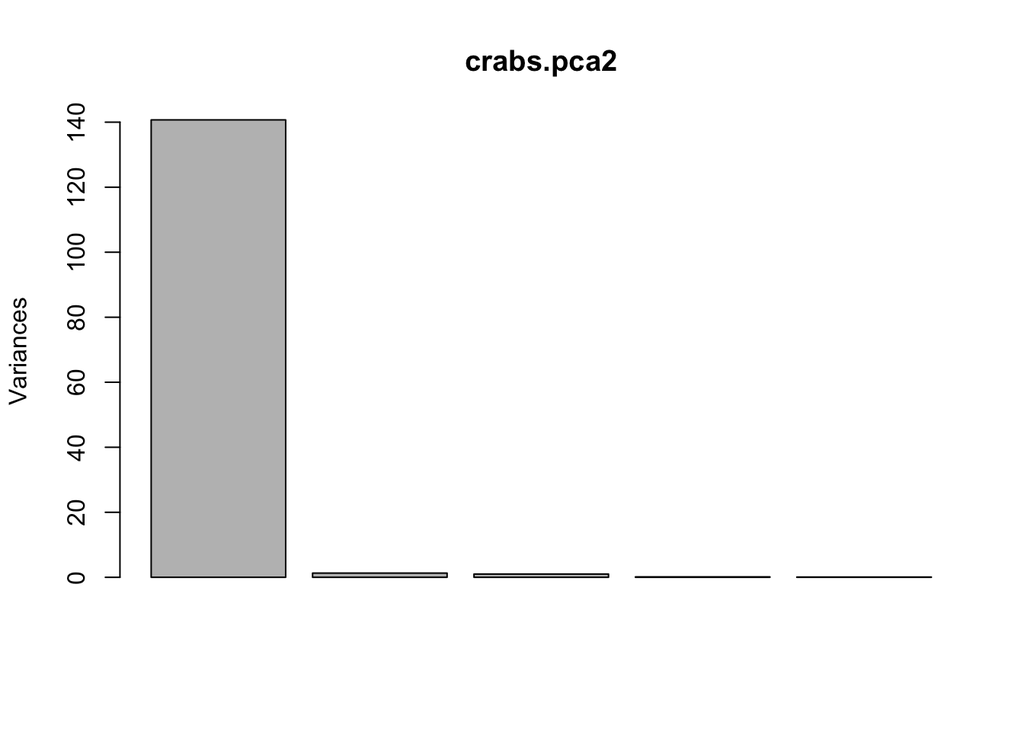

```r
crabs.pca2 <- prcomp(X, scale=FALSE) # Use the covariance matrix.
plot(crabs.pca2)
```

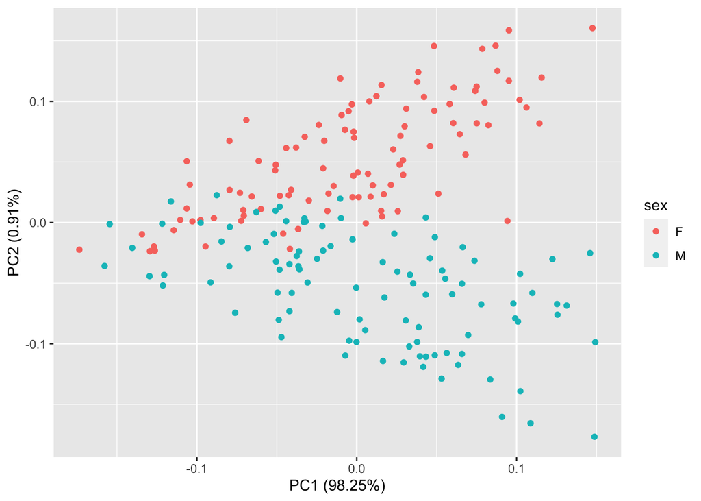

```r
autoplot(crabs.pca2, data = crabs, colour='sex')
```

```r
# not a big change
```

- Without doing any computation, think about what you expect the sample mean and sample covariance matrix to be for the PC scores. Check this numerically.

**Solution**

We’d expect the sample mean of the scores to be 0 and the sample variance to equal the eigenvalues

```r
colMeans(crabs.pca$x)
```

```
          PC1           PC2           PC3           PC4           PC5
 1.893624e-16  1.859971e-16 -3.253647e-16 -1.334002e-17  1.639270e-16
```

```r
apply(crabs.pca$x,2, sd)
```

```
       PC1        PC2        PC3        PC4        PC5
2.18834065 0.38946785 0.21594669 0.10552420 0.04137243
```

```r
crabs.pca$sdev
```

```
[1] 2.18834065 0.38946785 0.21594669 0.10552420 0.04137243
```

Now check other properties of the PC scores listed in proposition 4.2 in the notes.

**Solution**

The properties listed were specific to either the scaled, or unscaled PCA. Make sure you are using the right version when checking!

```r
cov(crabs.pca2$x)# diagonal,
```

```
              PC1           PC2           PC3           PC4           PC5
PC1  1.407057e+02  2.228389e-14 -5.365317e-15 -2.177835e-15  3.331807e-14
PC2  2.228389e-14  1.296837e+00 -7.858936e-15 -3.522723e-16 -2.558912e-16
PC3 -5.365317e-15 -7.858936e-15  1.000269e+00 -1.916030e-16 -3.291163e-16
PC4 -2.177835e-15 -3.522723e-16 -1.916030e-16  1.352993e-01  2.773949e-17
PC5  3.331807e-14 -2.558912e-16 -3.291163e-16  2.773949e-17  7.791423e-02
```

```r
#i.e. uncorrelated scores

sum(crabs.pca2$sdev^2)
```

```
[1] 143.216
```

```r
sum(diag(cov(X)))  #trace of covariance matrix
```

```
[1] 143.216
```

```r
prod(crabs.pca2$sdev^2)
```

```
[1] 1.924094
```

```r
det(cov(X))
```

```
[1] 1.924094
```

- Try the following transformations of the data…. Check the effect of each transformation on the principal components (the loadings/eigenvectors), the principal component scores, and the variance of the principal components (the eigenvalues).

**Translation**

Add a constant to each columns of X

```r
X2 = sweep(X,2, c(1,2,3,4,5), FUN="+")
#check
colMeans(X)
```

```
     FL      RW      CL      CW      BD
15.5830 12.7385 32.1055 36.4145 14.0305
```

```r
colMeans(X2)
```

```
     FL      RW      CL      CW      BD
16.5830 14.7385 35.1055 40.4145 19.0305
```

```r
#check its not changed anything
head(prcomp(X2)$x/crabs.pca2$x)
```

```
  PC1 PC2 PC3 PC4 PC5
1   1   1   1   1   1
2   1   1   1   1   1
3   1   1   1   1   1
4   1   1   1   1   1
5   1   1   1   1   1
6   1   1   1   1   1
```

So translating the data by a constant amount does not change PCA.

**Scaling**

If we scale by a diagonal matrix, this does change the scores, loadings, and variance in the unscaled PCA (using the covariance matrix), but does not affect PCA based on the correlation matrix.

```r
X3 = as.matrix(X) %*% diag(1:5)
# unscaled PCA
head(prcomp(X3)$x/crabs.pca2$x)
```

```
       PC1         PC2        PC3        PC4        PC5
1 3.501570 -2.90825484  -2.482006 -59.635776  0.4526624
2 3.528576 -0.73714597  -3.795646  -2.002687 -1.1752732
3 3.509788  2.20071465  18.954783   4.137683  1.1601186
4 3.513644  0.70733356  -8.179958   0.456134 10.2513676
5 3.534282  0.41827889  -4.778195  -4.095140 -0.6088965
6 3.475948  0.09625112 -17.735177  -3.472802 -1.3192753
```

```r
prcomp(X3)$sdev/crabs.pca2$sdev
```

```
[1] 3.534903 3.399749 2.274241 2.675349 1.641119
```

```r
prcomp(X3)$rotation/crabs.pca2$rotation
```

```
           PC1         PC2          PC3        PC4        PC5
[1,] 0.2819620  0.43176573  0.151237898 -0.2135542  7.7777053
[2,] 0.5620376  0.02340064 -2.331722289  1.3521470  0.8578779
[3,] 0.8487397 -0.48003534 -1.413070627  5.5847934  0.2241656
[4,] 1.1324711  1.83358040 -0.032304663  3.1220422  0.1593389
[5,] 1.4132958  5.20510558  0.003762158 -0.5861264 -0.2127435
```

```r
# scaled PCA
head(prcomp(X3, scale=TRUE)$x/crabs.pca$x)
```

```
  PC1 PC2 PC3 PC4 PC5
1   1   1   1   1   1
2   1   1   1   1   1
3   1   1   1   1   1
4   1   1   1   1   1
5   1   1   1   1   1
6   1   1   1   1   1
```

```r
prcomp(X3, scale=TRUE)$sdev/crabs.pca$sdev
```

```
[1] 1 1 1 1 1
```

```r
prcomp(X3, scale=TRUE)$rotation/crabs.pca$rotation
```

```
     PC1 PC2 PC3 PC4 PC5
[1,]   1   1   1   1   1
[2,]   1   1   1   1   1
[3,]   1   1   1   1   1
[4,]   1   1   1   1   1
[5,]   1   1   1   1   1
```

**Orthogonal rotations:**

If we multiply the data by an orthogonal matrix the scores and eigenvalues remain the same but the loadings/eigenvectors change.

```r
library(pracma)
U <- randortho(5)
X4 = as.matrix(X)%*% U

head(prcomp(X4)$x/crabs.pca2$x) # scores are the same
```

```
  PC1 PC2 PC3 PC4 PC5
1   1  -1  -1  -1  -1
2   1  -1  -1  -1  -1
3   1  -1  -1  -1  -1
4   1  -1  -1  -1  -1
5   1  -1  -1  -1  -1
6   1  -1  -1  -1  -1
```

```r
prcomp(X4)$sdev/crabs.pca2$sdev # eigenvalues the same
```

```
[1] 1 1 1 1 1
```

```r
prcomp(X4)$rotation/crabs.pca2$rotation
```

```
             PC1         PC2        PC3        PC4        PC5
[1,]  0.08793532  3.03071609  0.2379800  0.1063689  1.1013009
[2,] -2.21231025  0.05428520 -0.1548981  5.9088984 -1.3321807
[3,] -0.36888247 -0.95147911 -2.9001174  0.6233018  1.0861931
[4,] -0.87929229  0.03463467  1.1431730  2.7812215  1.0039483
[5,] -2.28818333 -0.30346316  1.1668809 -0.4879891 -0.6162623
```

```r
#  loadings/eigenvectors change.
```

### Q3

Download the final Premier League table for the 2022-23 season from https://www.rotowire.com/soccer/league-table.php?season=2022. There is a button to download the csv (comma separated variable) file in the bottom right hand corner. Note that you may need to manually delete the first row of the csv file before doing this.

Repeat the analysis done in the notes.

**Solution**

To delete the first row, I simply opened the file in Rstudio and manually deleted it.

```r
library(dplyr)
prem22 <- read.csv('prem202223.csv')
# the data can be downloaded from https://www.rotowire.com/soccer/league-table.php
table <- prem22 |> dplyr::select(Team, W, D, L, G, GA, GD)
knitr::kable(head(table,10), booktabs = TRUE, escape=FALSE)
```

| Team | W | D | L | G | GA | GD |
| --- | --- | --- | --- | --- | --- | --- |
| Manchester City | 28 | 5 | 5 | 94 | 33 | 61 |
| Arsenal | 26 | 6 | 6 | 88 | 43 | 45 |
| Manchester United | 23 | 6 | 9 | 58 | 43 | 15 |
| Newcastle United | 19 | 14 | 5 | 68 | 33 | 35 |
| Liverpool | 19 | 10 | 9 | 75 | 47 | 28 |
| Brighton & Hove Albion | 18 | 8 | 12 | 72 | 53 | 19 |
| Aston Villa | 18 | 7 | 13 | 51 | 46 | 5 |
| Tottenham Hotspur | 18 | 6 | 14 | 70 | 63 | 7 |
| Brentford | 15 | 14 | 9 | 58 | 46 | 12 |
| Fulham | 15 | 7 | 16 | 55 | 53 | 2 |

```r
tmp = table[,2:7]
rownames(tmp)=table$Team

prem.pca = prcomp(tmp, retx=TRUE, scale=TRUE)
prem.pca$rotation[,1]
```

```
          W           D           L           G          GA          GD
-0.45998030  0.05857796  0.45679455 -0.43021007  0.41006143 -0.47232871
```

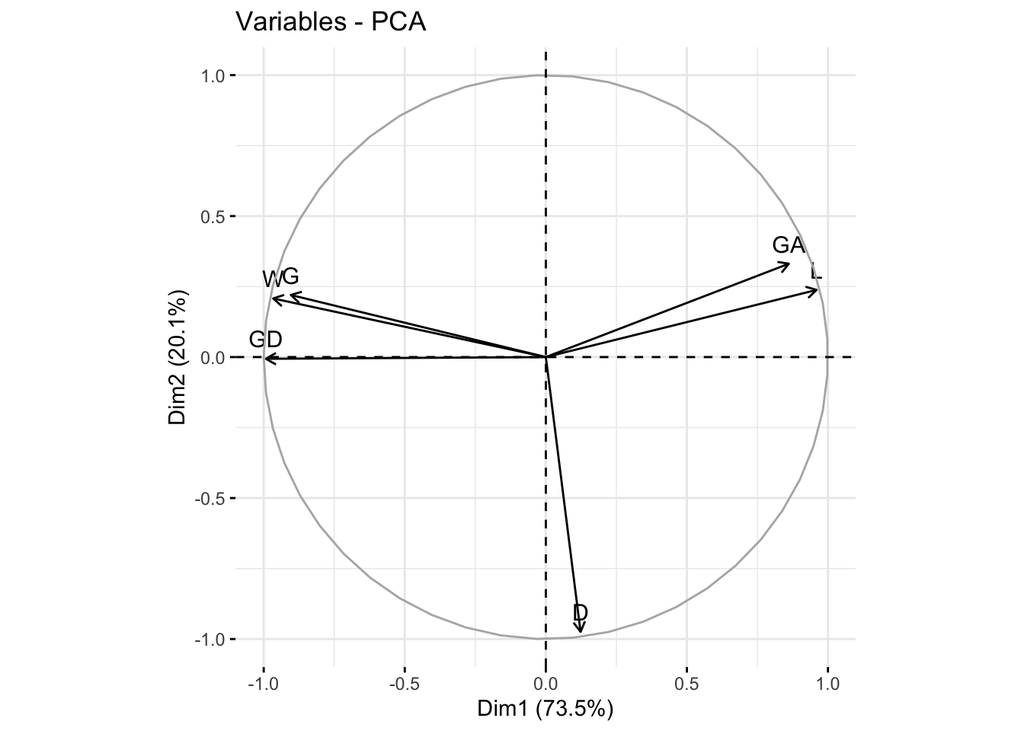

```r
fviz(prem.pca, element='var')
```

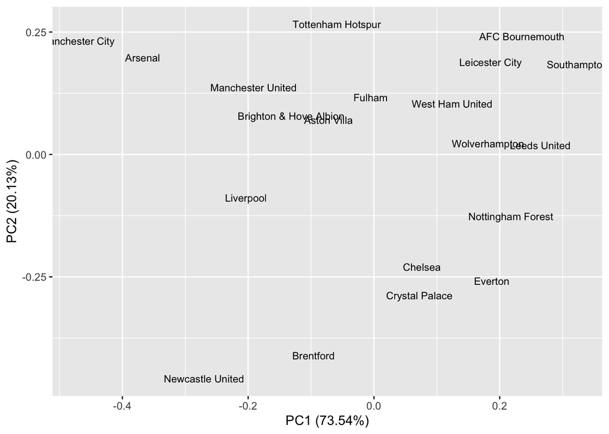

```r
autoplot(prem.pca, data = table,  label = TRUE,  label.size = 3, shape=FALSE)
```

PC1 is remarkably similar to the 2019-20 season. It contrasts goals against and losses vs goals for and wins (ie it measures if the team did well or not). PC2 is mainly measures the number of draws a team had. So Newcastle had lots of draws, and thus had a very small PC2 score. Manchester city won the legue so have the smallest PC1 score. Southampton finished bottom and have the largest PC1 score.

### Q4

The `decathlon2` data from the `factoextra` package contains data on 27 different decathletes’ performances during two different competitions. Let’s start by extracting their performance in the 10 different decathlon events at the Olympics.

```r
library("factoextra")
data(decathlon2)
X <- decathlon2|> dplyr::filter(Competition=='OlympicG') |> dplyr::select(-Rank, -Points,-Competition)
```

Conduct PCA on these data, thinking about whether it is appropriate to use the correlation or covariance matrix. Give a scree plot, and determine how much information in the data is retained by the first two PCs. Interpret the leading PCs.

Plot the first two scores for the different athlete performances, labelling each point. From these plots, comment on particular strengths/weaknesses in some performances.

**Solution**

Firstly, we must decide whether to use the correlation or covariance matrix. As these events are measured on very different scales it makes sense to use the correlation matrix.

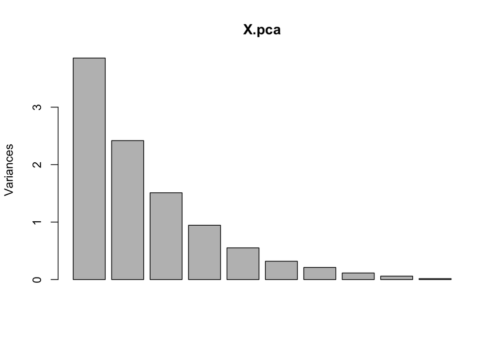

```r
X.pca <- prcomp(X, scale=TRUE)
plot(X.pca)
```

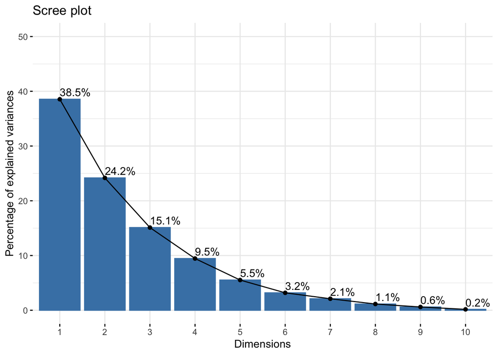

```r
fviz_eig(X.pca, addlabels = TRUE, ylim = c(0, 50))
```

The first 2 PCs explain 63% of the variance.

```r
cumsum(X.pca$sdev^2/sum(X.pca$sdev^2))
```

```
 [1] 0.3854650 0.6272574 0.7783056 0.8728147 0.9280123 0.9598797 0.9809328
 [8] 0.9923592 0.9983383 1.0000000
```

A circle plot can help with the interpretations:

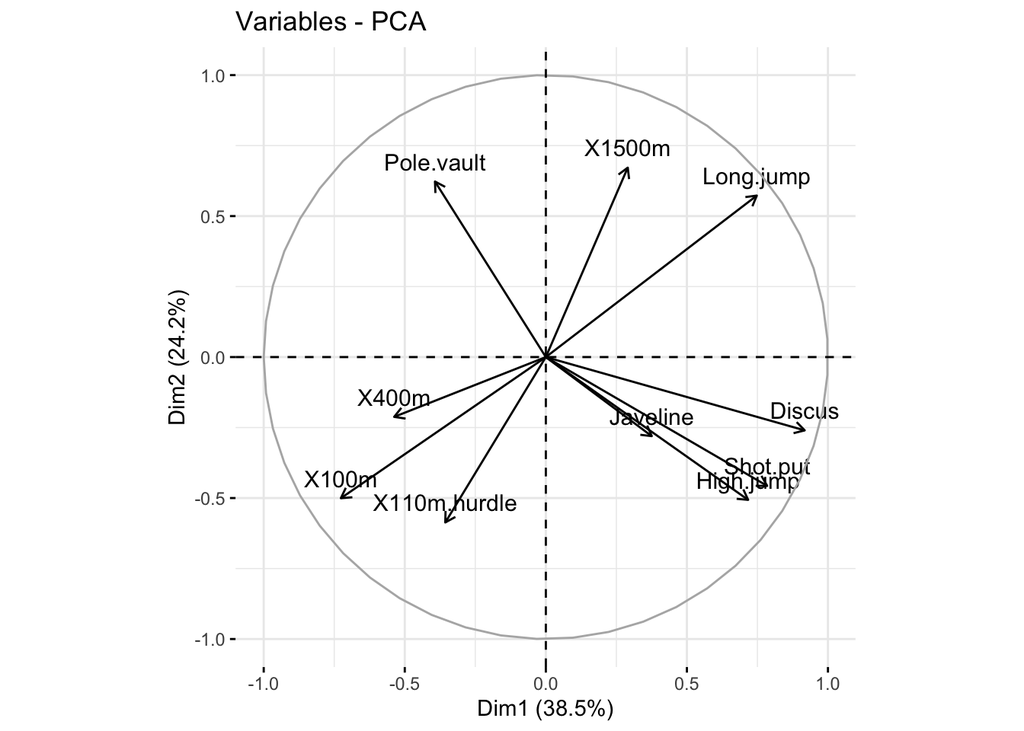

```r
fviz_pca_var(X.pca)
```

The first PC is an overall measure of performance. Recall that for throws and jumps, large values are good, whereas for track events, smaller values are good. So large values of PC1 would indicate good overall performance (short sprint times, long throws). PC1 is most strongly related to discus, 100m, shot put, and the high and long jump. Note that it is negatively correlated with pole vault and positively correlated with 1500m, which is opposite to what we’d expect if it was just measuring performance (albeit these correlations are small).

We can see that the sprint events are highly correlated with each other (100m, 400m , 110m hurdles), as are discuss, shot put and high jump.

The second PC contrasts performance in pole vault and long jump, against the other events. A high value of PC2 might indicate a good pole vault or long jump, and/or poor 1500m.

To illustrate the individual athlete performances, we can use the following plot:

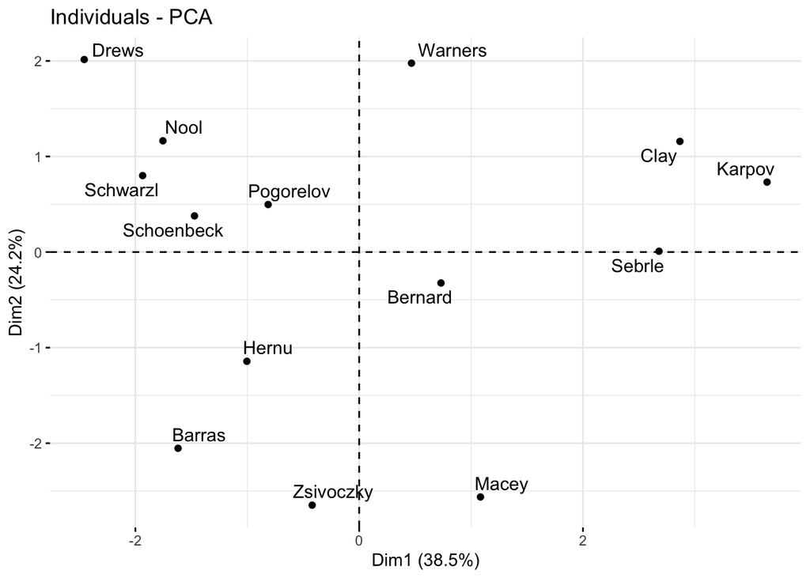

```r
fviz_pca_ind(X.pca,
             repel = TRUE # Avoid text overlapping (slow if many points)
             )
```

So we can see that the strong performances by Sebrle (1st), Clay (2nd), Karpov (3rd) and poor performance by Drews (last) etc.

Note that interpretation of PCA is not an exact science.